# Final Presentation

Keaton Markey  
3/25/2022

### Mental Health Today

- 40% of U.S. adults reported struggling with mental health or substance use
- Suicide is the second-leading cause of death among people aged 10-34
- The average delay between onset of mental illness symptoms and treatment is 11 years

Only gotten worse since COVID-19

- Are people getting the care, or able to get the care they need

### My Data

Two datasets:

- CDC's Behavioral Risk Factor Surveillance System (BRFSS)
- Substance Abuse & Mental Health Data Archive's National Mental Health Services Survey (N-MHSS)

Goal: Use these two datasets together to:

- get an overview of the state of mental health across the country
- and assess the availability of care and need

I explored these two separately and then together

### Severity of Mental Health

Now thinking about your mental health, which includes stress, depression, and problems with emotions, for how many days during the past 30 days was your mental health not good?

- 0 days, 1-13 days, or 14+ days

[output not shown]

### Severity of Mental Health

```r
data <- b1 %>%
  group_by(name) %>%
  summarise( per = sum(ifelse(ment14d == "14+", 1, 0))/n()) %>%
  distinct() %>%
  right_join(us_states, by = c("name" = "region"))

p <- ggplot(data, aes(x = long, y = lat,
                group = group, fill = per * 100)) +
  coord_map(projection = "albers", lat0 = 39, lat1 = 45) +
  geom_polygon(color = "#8d99ae", size = 0.1) +
  theme_map() + labs(fill = "Percent", title = "Percentage of Respondents Who Had \n14+ Bad Mental Health Days",
                     caption = "Data provided by BRFSS") +
  scale_fill_distiller(palette = "Spectral") +
  theme(text = element_text(size = 10))
```

### Are there any facilities in Kentucky?

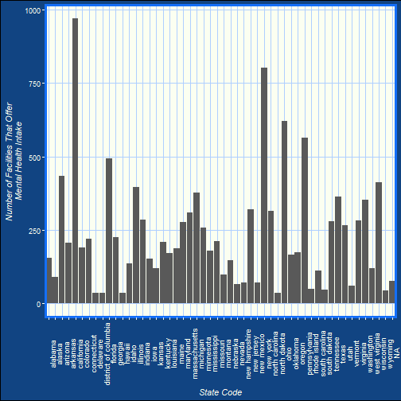

### Mental Health Facilities

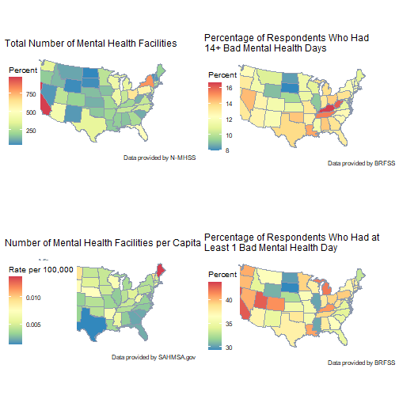

### Is this relationship significant?

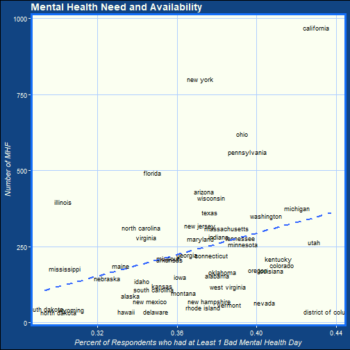

```r
mod1 <- lm(TOT ~ per, data = data)
summary(mod1)
```

```
Call:
lm(formula = TOT ~ per, data = data)

Residuals:
    Min      1Q  Median      3Q     Max
-325.02 -112.43  -32.73   52.20  622.96

Coefficients:
            Estimate Std. Error t value Pr(>|t|)
(Intercept)   -412.7      279.5  -1.476   0.1462
per           1767.4      754.6   2.342   0.0233 *
---
Signif. codes:  0 '***' 0.001 '**' 0.01 '*' 0.05 '.' 0.1 ' ' 1

Residual standard error: 185.4 on 49 degrees of freedom
Multiple R-squared:  0.1007,    Adjusted R-squared:  0.08232
F-statistic: 5.485 on 1 and 49 DF,  p-value: 0.02329
```

### What predicts bad mental health?

No idea.

```
      pred
actual      0      1
     0 187578  29536
     1  75751  51272
```

```
[1] 0.694055
```

```
      pred
actual      0      1
     0 188795  28319
     1  80280  46743
```

```
[1] 0.6844309
```

### Reflection

I think I took on too much at the beginning

I had to restructure my approach a couple of times

Future Directions:

- What influences where facilities are built?